# Reduccion 18

duraciones triangulares; plazo de 21 semanas; reducción y probabilidad

# Enunciado

Considere el proyecto cuyo cuadro de prelaciones, estimaciones de duración (mínima *a*, más probable *m* y máxima *b*, semanas, distribución triangular), duración tope y coste unitario de reducción (k€/semana) se adjunta; la columna *duration* es la duración esperada. Las actividades con CUR infinito no se pueden acelerar. El contrato exige entregar en **21 semanas**.

1. Con las duraciones esperadas el proyecto dura 23 semanas. Simule 5 000 réplicas y estime la probabilidad de entregar en 21 semanas sin acelerar.

2. Aplique Ackoff-Sasieni para reducir el proyecto hasta 21 semanas con las duraciones esperadas. ¿Qué probabilidad de cumplir el plazo da ahora esa reducción? Compruébelo simulando.

3. Construya la tabla de probabilidad de cumplir el plazo, duración media simulada y coste de reducción en función de las semanas recortadas (de 0 a 8). Use los mismos números aleatorios para todas las filas.

4. ¿Cuántas semanas hay que recortar para tener un 90 % de probabilidad de cumplir? ¿Cuánto cuesta frente a la reducción determinista? ¿Cuánto cuesta cada punto porcentual de probabilidad ganado en cada tramo?

Tabla 1: Cuadro de datos del enunciado

| activity | predecessor | duration | a | m | b | cap_duration | ucr |
| --- | --- | --- | --- | --- | --- | --- | --- |
| A | --- | 6 | 3 | 7 | 8 | 5 | 3.0 |
| B | --- | 5 | 4 | 5 | 6 | 3 | 1.0 |
| C | A,B | 3 | 2 | 3 | 4 | 2 | 3.0 |
| D | C | 7 | 4 | 8 | 9 | 6 | 2.0 |
| E | C | 3 | 1 | 3 | 5 | 1 | 4.0 |
| F | B | 3 | 2 | 3 | 4 | 1 | 3.0 |
| G | C | 8 | 6 | 8 | 10 | 6 | 6.0 |
| H | D,F,G | 3 | 2 | 3 | 4 | 2 | 1.0 |
| I | E,H | 3 | 1 | 3 | 5 | 3 | inf |

El proyecto corresponde a la organización de un congreso científico; las actividades son las siguientes (las duraciones del cuadro están en semanas).

Tabla 2: Descripción de las actividades

|  | Descripción |
| --- | --- |
| A | Definición del programa y fechas |
| B | Reserva de la sede |
| C | Convocatoria de comunicaciones |
| D | Página web e inscripciones |
| E | Contratación de ponentes invitados |
| F | Revisión de los trabajos recibidos |
| G | Elaboración del programa definitivo |
| H | Contratación de catering y viajes |
| I | Edición del libro de actas |

# Resolución

La duración esperada de una triangular es $(a + m + b)/3$; el cuadro la da ya redondeada en *duration*. Con esas duraciones esperadas se calcula el calendario determinista.

Tabla 3: Media de cada triangular frente a la duración esperada del cuadro

| activity | A | B | C | D | E | F | G | H | I |
| --- | --- | --- | --- | --- | --- | --- | --- | --- | --- |
| (a + m + b)/3 | (3 + 7 + 8)/3 = 6.00 | (4 + 5 + 6)/3 = 5.00 | (2 + 3 + 4)/3 = 3.00 | (4 + 8 + 9)/3 = 7.00 | (1 + 3 + 5)/3 = 3.00 | (2 + 3 + 4)/3 = 3.00 | (6 + 8 + 10)/3 = 8.00 | (2 + 3 + 4)/3 = 3.00 | (1 + 3 + 5)/3 = 3.00 |
| duration | 6 | 5 | 3 | 7 | 3 | 3 | 8 | 3 | 3 |

Cálculo de los tiempos mínimos y máximos de los nodos del grafo Roy paso a paso. El primer paso muestra el grafo resuelto; a partir del siguiente se calcula desde el principio (avance con los botones):

[figure not shown]

paso 0 de 24

[figure not shown]

Figura 1: Grafo Roy con las duraciones esperadas y el camino crítico

Tabla 4: Duración esperada de cada ruta

|  | actividades | duración = suma | duración |
| --- | --- | --- | --- |
| Route_1 | A – C – D – H – I | A(6) + C(3) + D(7) + H(3) + I(3) = 22 | 22.0 |
| Route_2 | A – C – E – I | A(6) + C(3) + E(3) + I(3) = 15 | 15.0 |
| Route_3 | A – C – G – H – I | A(6) + C(3) + G(8) + H(3) + I(3) = 23 | 23.0 |
| Route_4 | B – C – D – H – I | B(5) + C(3) + D(7) + H(3) + I(3) = 21 | 21.0 |
| Route_5 | B – C – E – I | B(5) + C(3) + E(3) + I(3) = 14 | 14.0 |
| Route_6 | B – C – G – H – I | B(5) + C(3) + G(8) + H(3) + I(3) = 22 | 22.0 |
| Route_7 | B – F – H – I | B(5) + F(3) + H(3) + I(3) = 14 | 14.0 |

## Apartado 1

1. Con las duraciones esperadas el proyecto dura 23 semanas. Simule 5 000 réplicas y estime la probabilidad de entregar en 21 semanas sin acelerar.

Cada réplica sortea una duración por actividad con su triangular; la duración del proyecto es el máximo de las rutas (τ = ‖R·t‖∞). La probabilidad de cumplir es la fracción de réplicas con τ ≤ plazo.

|  | mean | std | q05 | q50 | q95 | min | max |
| --- | --- | --- | --- | --- | --- | --- | --- |
| τ | 23.31 | 1.49 | 20.81 | 23.31 | 25.73 | 18.31 | 28.48 |

Sin acelerar: duración media simulada 23.31 semanas (determinista: 23) y P(τ ≤ 21) = 0.065.

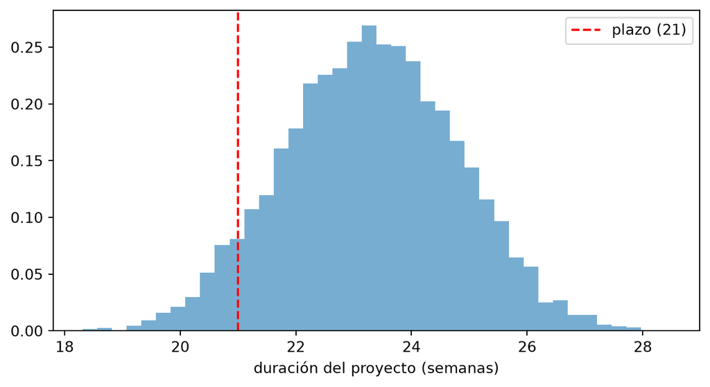

Figura 2: Distribución simulada de la duración sin acelerar

**Respuesta:** sin acelerar, la probabilidad de entregar en 21 semanas es P(τ ≤ 21) ≈ **0.065** (6.5 % de las 5 000 réplicas), con una duración media simulada de 23.31 semanas frente a las 23 deterministas. Para los apartados siguientes se usa `monte_carlo_crashing`, que repite la simulación para cada número de semanas recortadas con los mismos números aleatorios y **redondea cada duración sorteada a semanas enteras** (mínimo 1), como el resto del curso; con ese redondeo, sin recortar sale una media de 23.30 semanas y P(τ ≤ 21) = 0.137. La diferencia con 0.065 se debe al redondeo: una duración simulada de 21.4 semanas, por ejemplo, cuenta como 21 y cumple el plazo.

## Apartado 2

2. Aplique Ackoff-Sasieni para reducir el proyecto hasta 21 semanas con las duraciones esperadas. ¿Qué probabilidad de cumplir el plazo da ahora esa reducción? Compruébelo simulando.

Con las duraciones esperadas el proyecto dura 23 semanas: hay que recortar 23 − 21 = 2 semanas para llegar a 21.

En cada paso del algoritmo de Ackoff-Sasieni se acorta una semana la ruta crítica (o las rutas críticas) eligiendo, entre las actividades críticas con margen, la combinación de menor CUR que reduce *todas* las rutas críticas a la vez.

Tabla 5: Algoritmo de Ackoff-Sasieni con las duraciones esperadas hasta el plazo

[figure not shown]

paso -1 de 2

[figure not shown]

Algoritmo de Ackoff-Sasieni: tabla completa. Pulse «siguiente» para ver cómo se construye.

Tabla 6: Opciones consideradas en cada paso

| paso | duración | rutas críticas | opciones (coste) | elegida | coste del paso |
| --- | --- | --- | --- | --- | --- |
| 1 | 23 | Route_3 | H (1); A (3); C (3); G (6) | H | 1.0 |
| 2 | 22 | Route_3 | A (3); C (3); G (6) | A | 3.0 |

- **Paso 1** (23 semanas → 22 semanas). Ruta crítica: Route_3 (A – C – G – H – I). Opciones que acortan la ruta crítica (CUR en k€/semana): H (1); A (3); C (3); G (6). Se elige **H** (la actividad de la ruta crítica con margen y menor CUR), la opción más barata: 1 k€ por semana. Se reduce 1 semana: H llega a su duración tope (2 semanas). Sobrecoste: 1 × 1 = 1 k€; acumulado: **1 k€**.

- **Paso 2** (22 semanas → 21 semanas). Ruta crítica: Route_3 (A – C – G – H – I). Opciones que acortan la ruta crítica (CUR en k€/semana): A (3); C (3); G (6). Se elige **A** (la actividad de la ruta crítica con margen y menor CUR), la opción más barata: 3 k€ por semana (empata con C: cuestan lo mismo en este paso y el algoritmo toma la primera que encuentra). Se reduce 1 semana: A llega a su duración tope (5 semanas); Route_6 (B – C – G – H – I) alcanza la duración del proyecto (21 semanas) y pasa a ser crítica. Sobrecoste: 1 × 3 = 3 k€; acumulado: **4 k€**.

**Resultado:** la duración pasa de 23 semanas a 21 semanas con un sobrecoste de 1 + 3 = **4 k€**.

| paso | actividades acortadas | coste del paso | sobrecoste acumulado |
| --- | --- | --- | --- |
| 1 | H | 1.0 | 1.0 |
| 2 | A | 3.0 | 4.0 |

**Respuesta:** reducir las duraciones esperadas hasta 21 semanas exige 2 semanas de reducción y 1 + 3 = 4 k€ (duración determinista 21 semanas); pero, simulando, la probabilidad de cumplir es solo P(τ ≤ 21) = **0.460**: se cumple menos de la mitad de las veces: con la duración esperada justo en el plazo, el sesgo de fusión (en cada réplica manda la ruta que más se alarga) empuja la media por encima del plazo. Está lejos del 90 % que suele exigirse.

## Apartado 3

3. Construya la tabla de probabilidad de cumplir el plazo, duración media simulada y coste de reducción en función de las semanas recortadas (de 0 a 8). Use los mismos números aleatorios para todas las filas.

Para cada número de semanas recortadas $r$, la tabla da las reducciones que aplica Ackoff-Sasieni (una por paso, separadas por «;»), el coste acumulado, la duración determinista, la media y el percentil 90 simulados y la probabilidad de cumplir, siempre con las mismas 5 000 réplicas de duraciones redondeadas a semanas enteras (a cada réplica se le restan las semanas recortadas a cada actividad, sin bajar de 1 semana).

Tabla 7: Probabilidad de cumplir el plazo según las semanas recortadas

| periodos recortados | actividades acortadas (paso a paso) | duración determinista | coste | τ media | τ P90 | P(τ ≤ plazo) |
| --- | --- | --- | --- | --- | --- | --- |
| 0 | — | 23.0 | 0.0 | 23.302 | 25.0 | 0.137 |
| 1 | H | 22.0 | 1.0 | 22.302 | 24.0 | 0.312 |
| 2 | H; A | 21.0 | 4.0 | 21.638 | 24.0 | 0.460 |
| 3 | H; A; C | 20.0 | 7.0 | 20.638 | 23.0 | 0.722 |
| 4 | H; A; C; G | 19.0 | 13.0 | 20.023 | 22.0 | 0.837 |
| 5 | H; A; C; G; D + G | 18.0 | 21.0 | 19.023 | 21.0 | 0.956 |

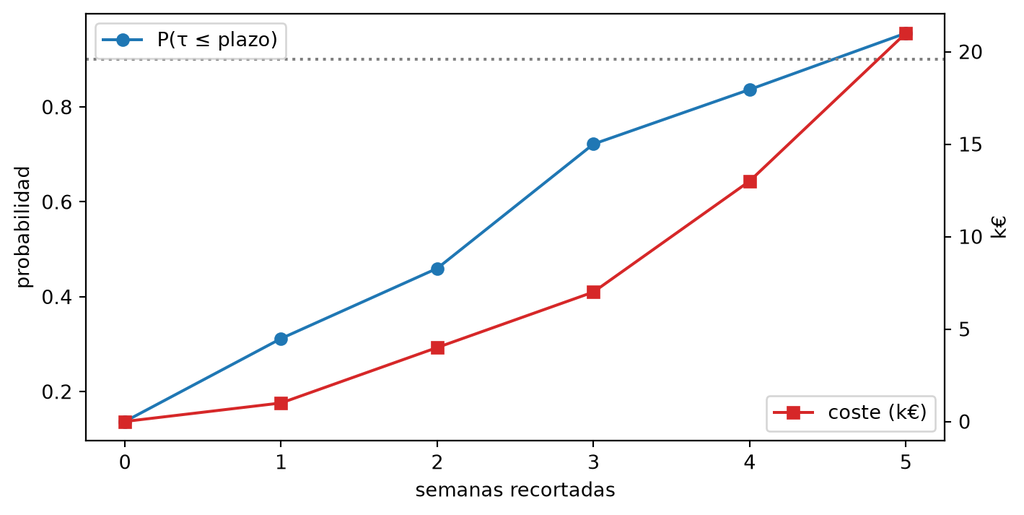

Figura 3: Probabilidad de cumplir y coste de reducción según las semanas recortadas

**Respuesta:** la tabla anterior. Al recortar, la probabilidad de cumplir sube de 0.137 (sin recortar) a 0.956 (5 semanas recortadas, 21 k€) y la duración media simulada baja de 23.30 a 19.02 semanas, siempre algo por encima de la determinista (sesgo de fusión). No se puede recortar más de 5 semanas: después no queda ninguna combinación con margen que acorte todas las rutas críticas (Ackoff-Sasieni se detiene).

## Apartado 4

4. ¿Cuántas semanas hay que recortar para tener un 90 % de probabilidad de cumplir? ¿Cuánto cuesta frente a la reducción determinista? ¿Cuánto cuesta cada punto porcentual de probabilidad ganado en cada tramo?

Coste de cada punto porcentual de probabilidad en cada tramo: lo que cuesta recortar esa semana dividido entre los puntos que gana la probabilidad, $\Delta\text{coste} / (100\,\Delta P)$.

| semanas recortadas | Δcoste (k€) | Δprobabilidad (puntos) | k€ por punto |
| --- | --- | --- | --- |
| 0 → 1 | 1 − 0 = 1 | 31.2 − 13.7 = 17.5 | 1 / 17.5 = 0.06 |
| 1 → 2 | 4 − 1 = 3 | 46.0 − 31.2 = 14.8 | 3 / 14.8 = 0.20 |
| 2 → 3 | 7 − 4 = 3 | 72.2 − 46.0 = 26.2 | 3 / 26.2 = 0.11 |
| 3 → 4 | 13 − 7 = 6 | 83.7 − 72.2 = 11.5 | 6 / 11.5 = 0.52 |
| 4 → 5 | 21 − 13 = 8 | 95.6 − 83.7 = 11.9 | 8 / 11.9 = 0.67 |

**Respuesta:** para tener al menos un 90 % de probabilidad hay que recortar **5 semanas** (P = 0.956), con un coste de **21 k€**, frente a 2 semanas y 4 k€ de la reducción determinista hasta el plazo (P = 0.460): la diferencia, 17 k€, es lo que cuesta la seguridad. El punto de probabilidad más barato se compra en el tramo 0 → 1 (0.06 k€) y el más caro en el tramo 4 → 5 (0.67 k€): los últimos puntos, cuando la probabilidad ya está cerca de 1, son los más caros.